# Guide for analysis of the Acumen Hypotension Prediction Index software by Edward Lifesciences

Nour Mamoun Abdul Rahman Al Said, Anne Sofie Gam Husted and Sif Michelsen Jonsdottir

```r
# To install VitalDBR and elma from github
library(devtools)
#install_github('legendenomgeorg/VitalDBR/VitalDBR')
library(VitalDBR)
#install_github('annesofiehusted/elma/elma')
library(elma)

# Other libraries needed
library(tidyverse)
library(seewave)
library(readxl)
library(naniar)
library(gsubfn)
```

# Introduction

This is a method for making an analysis of the Edwards Lifesciences monitor, specifically the Acumen Hypotension Prediction Index software. As Edwards Lifesciences has not made any data available, data must be generated, which is done by pulling data from the opensource database VitalDB. This data must be transformed to an analog signal, which will mimic a human arterial pressure, that can then be passed through the monitor.

When the data has been passed through the monitor, the data is analysed and the positive predictive value and sensitivity is calculated.

# Before Monitor

All data used in this project is from the opensource database VitalDB, as previously stated.

The code below is an example of how to find which cases should be passed through the monitor. In this example it is specified, that the cases must be from open general surgery with general anesthesia. Other specifications can be found at https://vitaldb.net/dataset/.

```r
cases <- VitalDBR::load_VDB("https://api.vitaldb.net/cases") %>%
      dplyr::filter(approach=="Open",
                    department=="General surgery",
                    ane_type=="General")
```

From the dataset ‘cases’ it can be seen which cases meet the criteria listed. To download a specific case, the code below can be used. It should be specified which case id is wanted, and what type of data we want from this case. For this analysis the only data needed is the arterial pressure, which is called ‘SNUADC/ART’ in the VitalDB database.

```r
vitalDB_case50 <- VitalDBR::load_case(tname = 'SNUADC/ART', caseid = 50)
```

To get an idea of what the data looks like, it is plotted in the code below.

It is worth noting that there is noise in the beginning and at the end of the data. This is likely caused by the medical crew turning on the equipment before it is attached to the patient.

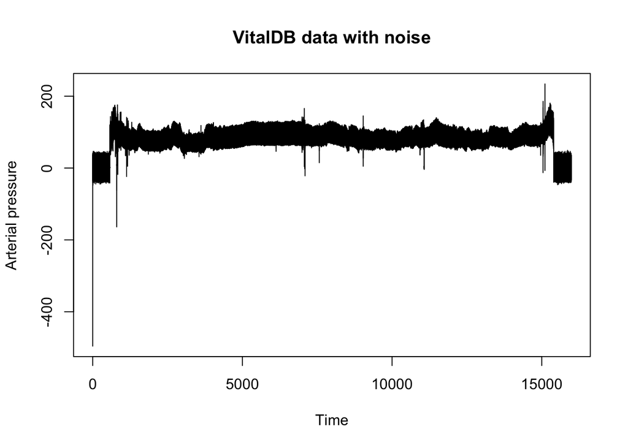

```r
plot(vitalDB_case50$Time, vitalDB_case50$SNUADC.ART, type = 'l',main = "VitalDB data with noise", xlab = "Time", ylab = "Arterial pressure")
```

To remove the noise the function ‘remove_noise’ is used from the package ‘elma’.

```r
vitalDB_case50 <- remove_noise(vitalDB_case50)
```

The data without the noise is then plotted:

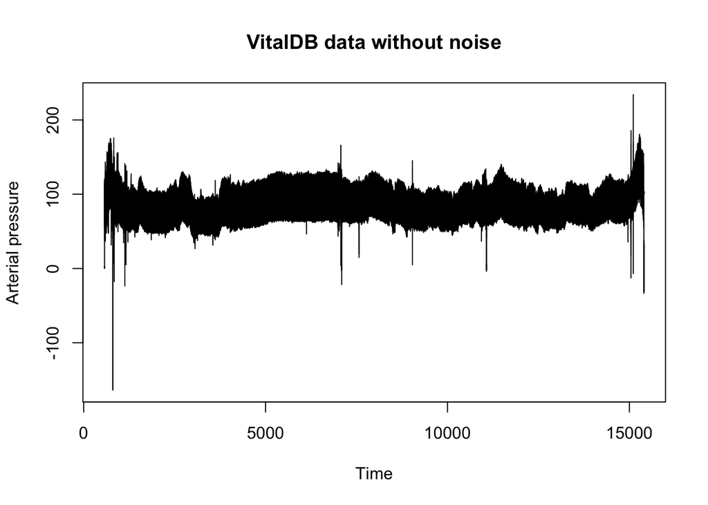

```r
plot(vitalDB_case50$Time, vitalDB_case50$SNUADC.ART, type = 'l', main = "VitalDB data without noise", xlab = "Time", ylab = "Arterial pressure")
```

The arterial pressure is with 500 Hz. For it to be compatible with the monitor, it needs to be upsampled to 1000 Hz. This is done using the package ‘seewave’.

```r
up_vitalDB_case50 <- as.data.frame(seewave:::resamp(vitalDB_case50[,2], 500, 1000, output='sample'))
```

To verify that the arterial pressure curve is still the same, just with double the amount of data points, the upsampled data is plotted on top of the original data from VitalDB.

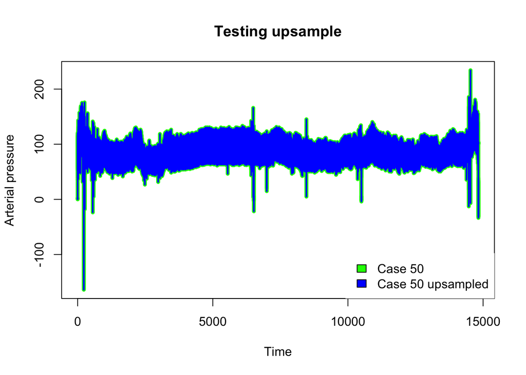

Before making the CSV file that then can be put through the monitor, the analog signal needs to be the same as the arterial pressure. This will not be the case as is, as the analog signal is being processed as soundwaves, that are at a higher voltage than the arterial pressure. To make up for this we made a breadboard with two resistors, but as these resistors were not the exact value needed to reduce the voltage, we divide our arterial pressure with 96.2.

```r
up_vitalDB_case50$SNUADC.ART <- up_vitalDB_case50$SNUADC.ART/96.2

write_csv(up_vitalDB_case50, "Case50.csv", col_names = FALSE)
```

To get the data properly through the monitor the sex, age, height, and weight of the case patient is also needed, as the Acumen Hypotension Prediction Index software needs this information to calculate the HPI. This can be obtained by running the code below.

```r
cases %>% filter(caseid == 50) %>%
  select(age, sex, height, weight)
```

```
##   age sex height weight
## 1  47   F  158.1   51.6
```

When this is done the data is ready to be passed through the monitor.

# After monitor

When multiple cases have been passed through the monitor, the function ‘confusion_matrix’ can run through all files and give out the values obtained from the forward backward analysis for each case.

It is important to note that for the function ‘confusion_matrix’ to work properly, the files from the monitor must be named ‘Casexxx’, where xxx is the case id. So for the example of case id 50, the file from the monitor should be named ‘Case50’.

The values returned in the confusion matrix are for the forward analysis late alarms, medical intervention, true positives, false positives. Late alarms are alarms that went off less than a minute before the hypotensive event

The medical interventions are defined as either a positive difference of five or higher between two consecutive MAP values or a positive difference of eight or higher in a two minute interval.

For the backward analysis the values returned are ongoing alarms, true positives, and false negatives. An ongoing alarm is an alarm that started before we enter the interval of inspection.

The function takes arguments ‘directory’, ‘minutes’ and ‘HPI’, where the ‘directory’ is your directory containing the files from the monitor. ‘minutes’ is the time interval you want to give the forward and backward analysis, so the amount of minutes you want to look ahead or back from an event. ‘HPI’ is a boolean value, TRUE/FALSE, depending on whether you want the alarm to be defined by HPI (True) or MAP (False).

While the function is running it prints the name of the file it is currently analysing, so you can see how far along it is.

Here the files with the monitor data is stored at the working directory. The analysis looks at 5 minute intervals and the alarm is defined by HPI.

```r
conf_HPI <- confusion_matrix(getwd(), 5, TRUE)
```

```
## [1] "Case111.xlsx"
## [1] "Case181.xlsx"
## [1] "Case185.xlsx"
## [1] "Case189.xlsx"
## [1] "Case210.xlsx"
## [1] "Case217.xlsx"
## [1] "Case232.xlsx"
## [1] "Case239.xlsx"
## [1] "Case295.xlsx"
## [1] "Case321.xlsx"
## [1] "Case348.xlsx"
## [1] "Case363.xlsx"
## [1] "Case409.xlsx"
## [1] "Case50.xlsx"
## [1] "Case52.xlsx"
## [1] "Case58.xlsx"
## [1] "Case60.xlsx"
## [1] "Case97.xlsx"
```

To calculate the positive predictive value and sensitivity from the confusion matrix the function ‘calculate_ppv_sens’ is used. For this function the input is simply the confusion matrix obtained above.

```r
gt(calculate_ppv_sens(conf_HPI))
```

| Positive_Predictive_Value | Sensitivity |
| --- | --- |
| 0.3898305 | 0.8615385 |

Run the code below to analyse a 5 minute intervals where the alarm is defined by MAP, and then calculate the positive predictive value and sensitivity.

```r
conf_MAP <- confusion_matrix(getwd(), 5, FALSE)
```

```
## [1] "Case111.xlsx"
## [1] "Case181.xlsx"
## [1] "Case185.xlsx"
## [1] "Case189.xlsx"
## [1] "Case210.xlsx"
## [1] "Case217.xlsx"
## [1] "Case232.xlsx"
## [1] "Case239.xlsx"
## [1] "Case295.xlsx"
## [1] "Case321.xlsx"
## [1] "Case348.xlsx"
## [1] "Case363.xlsx"
## [1] "Case409.xlsx"
## [1] "Case50.xlsx"
## [1] "Case52.xlsx"
## [1] "Case58.xlsx"
## [1] "Case60.xlsx"
## [1] "Case97.xlsx"
```

```r
gt(calculate_ppv_sens(conf_MAP))
```

| Positive_Predictive_Value | Sensitivity |
| --- | --- |
| 0.3037975 | 0.8484848 |